# Project_563

Jaswinder Kaur

2025-04-02

For this project I’m planning to use a genomic and phenomic dataset from the following paper: https://pmc.ncbi.nlm.nih.gov/articles/PMC6829122/

I accessed the dataset from Dryad: https://datadryad.org/dataset/doi:10.5061/dryad.xksn02vb9

The data is an Maize genotypic and phenotypic data, where they were doing genomic prediction and selections using traditional tools like Asreml. In my research I mostly deal with data like this, which led me to choose this data for this project. The goal for this project would be predicton of yield using the genotypic and phenotypic information from the training set to build a predictive model, and then predict yield for the testing set based on its genomic data only.

The phenotypic file has three phenotypes, instead of doing multivariate model predicting ( which I am not much aware about) I restricted myself to just doing univariate model and I decided to predict yield(YLD) and consider that as a response variable, because that is the most common response variable used in plant breeding so it was relatable and the information is easily applied to my own research directly.

### Data cleaning and transformation

Also ~40000 markers were present in the genotypic file, working with such big data is computationally challenging. So for this project, I did do dimentionality reduction using PCA and relatined the first 10 PCs and use those as genotypic data.

Lets Start!

```r
options(repos = c(CRAN = "https://cran.rstudio.com/"))
library(dplyr)
library(caret)
library(ISLR2)
library(tidyverse)
```

```r
library(ggplot2)

## Read and preprocess data
pheno <- read_csv("~/Downloads/maize_pheno.csv")
head(pheno)
```

```
## # A tibble: 6 × 4
##   ID        HT     FT    YLD
##   <chr>  <dbl>  <dbl>  <dbl>
## 1 A      0.613  0.555  0.767
## 2 A12   -0.809 -1.17  -0.886
## 3 A15   -1.16  -1.86  -1.16
## 4 A155  -1.09  -1.55  -1.68
## 5 A171  -0.560 -1.30  -1.36
## 6 A188  -1.38  -1.24  -0.836
```

```r
summary(pheno)
```

```
##       ID                  HT                FT                YLD
##  Length:391         Min.   :-2.7649   Min.   :-1.99987   Min.   :-2.10408
##  Class :character   1st Qu.:-0.6313   1st Qu.:-0.63265   1st Qu.:-0.74318
##  Mode  :character   Median : 0.0799   Median :-0.01779   Median :-0.01612
##                     Mean   : 0.0000   Mean   : 0.00000   Mean   : 0.00000
##                     3rd Qu.: 0.6844   3rd Qu.: 0.55340   3rd Qu.: 0.64880
##                     Max.   : 2.7469   Max.   : 2.82589   Max.   : 3.36440
```

```r
##instead of using all the phenotype I will use yield as the response and as our main phenotype
pheno_data <- pheno %>%
  select(ID, YLD)

##read the genotypic file
geno <- read_csv("~/Downloads/maize_gene.csv")
##check for the missing values
missing <- sapply(pheno, function(x) sum(is.na(x)))
missing
```

```
##  ID  HT  FT YLD
##   0   0   0   0
```

```r
##check for the missing values
missing <- sapply(geno, function(x) sum(is.na(x)))


# Remove the 'ID' column
gene_data <- geno[, -1]

## Scale the data
gene_data_scaled <- scale(gene_data)

## Apply PCA on the scaled genotype data
pca_result <- prcomp(gene_data, center = TRUE, scale. = TRUE)

## Select the top 10 principal components
pca <- data.frame(pca_result$x[, 1:10])

# Check the variance explained by these top PCs
explained_variance <- summary(pca_result)$importance[2, 1:10]
print(explained_variance)
```

```
##     PC1     PC2     PC3     PC4     PC5     PC6     PC7     PC8     PC9    PC10
## 0.03488 0.02438 0.02035 0.01939 0.01828 0.01465 0.01406 0.01281 0.01215 0.01044
```

```r
merge_data <- cbind(pheno_data, pca)
head(merge_data)
```

```
##     ID        YLD       PC1        PC2       PC3        PC4         PC5
## 1    A  0.7668724 -2.308499 -19.068387  31.76464 -47.469243 17.90754875
## 2  A12 -0.8861022 17.545288  -9.179009 -10.42257 -10.451653 -8.31032285
## 3  A15 -1.1595266 12.675049 -24.057363 -12.36702  -4.031689 -0.09581397
## 4 A155 -1.6815186 16.129913 -16.063330 -10.62828  -1.566715 -6.75371569
## 5 A171 -1.3583807 15.750826 -19.954125 -12.08601  -2.119905 -3.40136575
## 6 A188 -0.8363887 18.437536 -17.771570 -10.69495   4.845328 -2.45042747
##          PC6         PC7        PC8        PC9      PC10
## 1 -91.082208 17.69314622 -26.099731  0.5864932 -36.73099
## 2   5.356476 -0.02669864  -4.309855 -7.9788345  18.13151
## 3  -3.143988  5.05067497   9.244358  2.0932352  25.66016
## 4  -4.859322 -1.64900793  -7.190223  8.9030347  13.55536
## 5   7.844447  0.60179988   5.145712  3.7680668  15.00623
## 6   3.271446 -0.67327710   7.236273  5.5404934  10.32702
```

```r
##lets split the data in 70/30 proportion, we will use genotype and we will use YLD = yeild as phenotype
set.seed(123)
index <- createDataPartition(merge_data$YLD,
                             p = 0.7,
                             list = FALSE,
                             times = 1
                             )

##create trainign and test dataset
train <- merge_data[index, ]
test <- merge_data[-index, ]

##remove the ID so that ID is not used as a predictor
train_no_id <- train[, !names(train) %in% c("ID")]
test_no_id <- test[, !names(test) %in% c("ID")]
```

## Lets start with KNN models

We will use genotype data as the predictors and phenotype as respone Also, we will compare these models based on 10 fold CV and RMSE as our metric

Model Description:

Type: Non-parametric model Tuning Parameters: k (number of neighbors) Inference: This model is not suitable for inference, as it doesn’t produce a direct model equation; instead, it works by comparing individual data points Variable Selection: kNN does not explicitly perform variable selection, though irrelevant features may have less impact if they don’t influence the nearest neighbors. Standardization: Yes, kNN is sensitive to the scale of the features since it relies on distance metrics (Euclidean or others)

```r
tc <- trainControl(method = "cv",
                   number = 10)


Knn <- train( YLD ~ .,
              data = train_no_id,
              method = "knn",
              trControl = tc,
              tuneGrid = data.frame(k = 1:60))


##leys find the best k
Knn$results |>
  filter(k == Knn$bestTune$k)
```

```
##    k      RMSE  Rsquared     MAE    RMSESD RsquaredSD      MAESD
## 1 32 0.8832014 0.2655393 0.69875 0.1168689  0.1287624 0.07978279
```

```r
## lets fit the model again wth the best tuning parameter
knn_best <- train( YLD ~ .,
              data = train_no_id,
              method = "knn",
              trControl = trainControl(method = "none"),
              tuneGrid = Knn$bestTune)
knn_best$finalModel
```

```
## 32-nearest neighbor regression model
```

```r
##predict on our test set and comute the RMSE
predict_knn <- predict(knn_best, newdata = test_no_id)
knn_rmse <- sqrt(mean((test$YLD - predict_knn)^2))
print(paste("KNN RMSE:", knn_rmse))
```

```
## [1] "KNN RMSE: 0.827988075987162"
```

```r
##merge the predicting ID
Predict_knn_id <- data.frame(ID = test$ID, predict_yld = predict_knn)
head(Predict_knn_id)
```

```
##     ID predict_yld
## 1    A -0.03398137
## 2  A12 -0.38857861
## 3  A15 -0.31672703
## 4 A155 -0.62704816
## 5 A258 -0.08175296
## 6 A374  0.08913728
```

## Regularised Linear Regression

Type: Parametric model (assumes a linear relationship between the predictors and target). Tuning Parameters: Regularization strength (alpha for Lasso, lambda for Ridge). Inference: Yes, linear regression can be used for inference, as it provides estimates for the coefficients and hypothesis testing. Variable Selection: Yes, Lasso (L1) regularization performs implicit variable selection by shrinking some coefficients to zero. Standardization: Yes, especially when regularization is used, to ensure that all features contribute equally.

```r
library(glmnet)
##lets do a qucik fit to check the values for alpha and lamda
tuning_grid <- expand.grid(alpha = seq(from = 0, to = 1, length = 15),
                           lambda = seq(from = 0, to = 0.5, length = 15))

##train the model
lr <- train( YLD ~ .,
              data = train_no_id,
              method = "glmnet",
             preProcess = c("center", "scale"),
              trControl = tc,
              tuneGrid = tuning_grid)
##best paraeters
lr$bestTune
```

```
##   alpha    lambda
## 4     0 0.1071429
```

```r
lr$bestTune |>
  knitr::kable()
```

|  | alpha | lambda |
| --- | --- | --- |
| 4 | 0 | 0.1071429 |

```r
## lets fit the model again wth the best tuning parameter
lr_best <- train( YLD ~ .,
              data = train_no_id,
              method = "glmnet",
             preProcess = c("center", "scale"),
              trControl = trainControl(method = "none"),
              tuneGrid = lr$bestTune)

##predict on our test set and comute the RMSE
predict_lr <- predict(lr_best, newdata = test_no_id)
lr_rmse <- sqrt(mean((test$YLD - predict_lr)^2))
print(paste("LR RMSE:", knn_rmse))
```

[output not shown]

```r
##merge the predicting ID
Predict_LR_id <- data.frame(ID = test$ID, predict_yld = predict_lr)
head(Predict_LR_id)
```

```
##      ID predict_yld
## 1     A -0.25773842
## 2   A12 -0.10631427
## 3   A15  0.03837783
## 4  A155 -0.31534075
## 9  A258 -0.29339687
## 14 A374 -0.29246895
```

## Generalized Additive Models

Type: Non-parametric model (allows for non-linear relationships by using smooth functions of the predictors). Tuning Parameters: Smoothing parameter (s), number of basis functions. Inference: Yes, the smooth functions can be interpreted to understand the relationships between predictors and the target variable. Variable Selection: Implicitly performed through the use of smooth terms. Standardization: Not strictly necessary, though it may help with numerical stability.

```r
library(gam)
# Combine the train and test datasets for the entire dataset
final_gam_data <- rbind(train_no_id, test_no_id)

# Fit the GAM model using the combined PCA data
GAM <- gam(YLD ~ ., data = final_gam_data)
summary(GAM)
```

```
##
## Call: gam(formula = YLD ~ ., data = final_gam_data)
## Deviance Residuals:
##      Min       1Q   Median       3Q      Max
## -1.92108 -0.59776 -0.03214  0.50241  2.98707
##
## (Dispersion Parameter for gaussian family taken to be 0.7706)
##
##     Null Deviance: 390 on 390 degrees of freedom
## Residual Deviance: 292.8324 on 380 degrees of freedom
## AIC: 1020.569
##
## Number of Local Scoring Iterations: 2
##
## Anova for Parametric Effects
##            Df  Sum Sq Mean Sq F value    Pr(>F)
## PC1         1  20.372 20.3720 26.4361 4.370e-07 ***
## PC2         1   7.271  7.2710  9.4354 0.0022817 **
## PC3         1   7.562  7.5621  9.8131 0.0018671 **
## PC4         1   2.649  2.6490  3.4375 0.0645068 .
## PC5         1  11.536 11.5355 14.9693 0.0001286 ***
## PC6         1   0.013  0.0126  0.0164 0.8981891
## PC7         1  17.900 17.8997 23.2279 2.084e-06 ***
## PC8         1  17.091 17.0913 22.1789 3.488e-06 ***
## PC9         1  10.197 10.1973 13.2328 0.0003131 ***
## PC10        1   2.577  2.5771  3.3442 0.0682241 .
## Residuals 380 292.832  0.7706
## ---
## Signif. codes:  0 '***' 0.001 '**' 0.01 '*' 0.05 '.' 0.1 ' ' 1
```

```r
# Predict on the entire dataset
gam_pred_final <- predict(GAM, newdata = final_gam_data)

# Calculate RMSE on the entire dataset
gam_rmse_final <- sqrt(mean((final_gam_data$YLD - gam_pred_final)^2))
print(paste("Final GAM RMSE on entire dataset: ", gam_rmse_final))
```

```
## [1] "Final GAM RMSE on entire dataset:  0.865408488986923"
```

```r
# Merge the predicted values with the IDs from the original dataset
final_predictions <- data.frame(ID = c(train$ID, test$ID), predict_yld = gam_pred_final)
head(final_predictions)
```

```
##      ID  predict_yld
## 5  A171 -0.183608682
## 6  A188 -0.181926101
## 7  A208 -0.009777004
## 8  A239 -0.295401871
## 10 A305 -0.259311260
## 11 A321 -0.305256315
```

## Decision tree

Type: Non-parametric model (uses decision rules based on splitting features to predict the target). Tuning Parameters: Maximum depth of the tree, minimum samples required to split a node. Inference: Yes, decision trees can be interpreted through the tree structure and decision rules. Variable Selection: Implicitly performed as the tree splits on the most important features. Standardization: No, decision trees do not require standardization as they are not sensitive to feature scaling.

```r
# Example for Decision Tree
Decison_tree <- train(YLD ~ .,
                   data = train_no_id,
                   method = "rpart",
                   trControl = tc,
                   tuneGrid = expand.grid(cp = seq(0.01, 0.1, by = 0.01)))
Decison_tree
```

```
## CART
##
## 275 samples
##  10 predictor
##
## No pre-processing
## Resampling: Cross-Validated (10 fold)
## Summary of sample sizes: 248, 248, 248, 247, 247, 248, ...
## Resampling results across tuning parameters:
##
##   cp    RMSE       Rsquared    MAE
##   0.01  1.0618242  0.10679088  0.8461330
##   0.02  1.0097934  0.08858511  0.7968910
##   0.03  0.9734607  0.11561669  0.7594360
##   0.04  0.9806473  0.09952882  0.7737371
##   0.05  0.9929892  0.08627785  0.7894134
##   0.06  0.9961469  0.08640488  0.7925036
##   0.07  0.9961469  0.08640488  0.7925036
##   0.08  1.0051212  0.07570753  0.8009568
##   0.09  1.0051212  0.07570753  0.8009568
##   0.10  1.0101548  0.07386995  0.8032188
##
## RMSE was used to select the optimal model using the smallest value.
## The final value used for the model was cp = 0.03.
```

```r
# View the best tuning parameters
print(Decison_tree$bestTune)
```

```
##     cp
## 3 0.03
```

```r
Decison_tree_best <- train(YLD ~ .,
                   data = train_no_id,
                   method = "rpart",
                   trControl = trainControl(method = "none"),
                   tuneGrid = Decison_tree$bestTune)

print(Decison_tree_best)
```

```
## CART
##
## 275 samples
##  10 predictor
##
## No pre-processing
## Resampling: None
```

```r
# Make predictions on the test set
dt_pred <- predict(Decison_tree_best, newdata = test_no_id)

# Calculate RMSE
dt_rmse <- sqrt(mean((dt_pred - test_no_id$YLD)^2))
print(paste("decision tree RMSE: ", dt_rmse))
```

```
## [1] "decision tree RMSE:  0.904320901630675"
```

## Random forest model

Type: Non-parametric model (combines multiple decision trees to improve predictive performance). Tuning Parameters: Number of trees (ntree), number of variables to consider at each split (mtry). Inference: Yes, random forests can provide variable importance measures but are less interpretable than individual trees. Variable Selection: Implicitly performed by the algorithm (variable importance measures can be extracted). Standardization: No, random forests do not require feature scaling.

```r
install.packages("randomForest")
library(randomForest)
set.seed(12)
# Define the tuning grid for Random Forest parameters
tuning_grid <- expand.grid(
  mtry = c(2, 3, 4, 5, 6)
)

# Train the model with cross-validation
rf_tuned <- train(
  YLD ~ .,
  data = train_no_id,
  method = "rf",
  trControl = tc,
  tuneGrid = tuning_grid
)

print(rf_tuned$bestTune)
```

```
##   mtry
## 1    2
```

```r
# Re-fit the model with the best mtry value
rf_best <- randomForest(
  YLD ~ .,
  data = train_no_id,
  mtry = rf_tuned$bestTune$mtry
)
print(rf_best)
```

```
##
## Call:
##  randomForest(formula = YLD ~ ., data = train_no_id, mtry = rf_tuned$bestTune$mtry)
##                Type of random forest: regression
##                      Number of trees: 500
## No. of variables tried at each split: 2
##
##           Mean of squared residuals: 0.8144585
##                     % Var explained: 19.95
```

```r
# Make predictions on the test set
rf_pred <- predict(rf_best, newdata = test_no_id)

# Calculate RMSE
rf_rmse <- sqrt(mean((rf_pred - test_no_id$YLD)^2))
print(paste("Random Forest RMSE: ", rf_rmse))
```

```
## [1] "Random Forest RMSE:  0.794832118820093"
```

## SVM

Type: Parametric/non-parametric model (depends on the kernel; linear is parametric, radial is non-parametric). Tuning Parameters: Regularization parameter (C), kernel type (linear, radial), kernel parameters (gamma). Inference: No, SVMs are generally not interpretable, but you can report margins and support vectors. Variable Selection: Implicitly performed by the support vectors. Standardization: Yes, SVMs are sensitive to the scale of features.

```r
library(kernlab)
mod_svm <- train(YLD ~ .,
                 data = train_no_id,
                 method = "svmRadial",
                 trControl = tc,
                 tuneGrid = expand.grid(sigma = seq(0.01, 0.1, by = 0.01),
                                        C = 1:5))

mod_svm
```

```
## Support Vector Machines with Radial Basis Function Kernel
##
## 275 samples
##  10 predictor
##
## No pre-processing
## Resampling: Cross-Validated (10 fold)
## Summary of sample sizes: 247, 247, 247, 247, 247, 248, ...
## Resampling results across tuning parameters:
##
##   sigma  C  RMSE       Rsquared   MAE
##   0.01   1  0.8978919  0.2227668  0.7001664
##   0.01   2  0.8999842  0.2198064  0.6996061
##   0.01   3  0.9011598  0.2212981  0.6987285
##   0.01   4  0.9038592  0.2199415  0.7004541
##   0.01   5  0.9055139  0.2191406  0.7017181
##   0.02   1  0.8991433  0.2223889  0.6971960
##   0.02   2  0.9042855  0.2184322  0.6998331
##   0.02   3  0.9100133  0.2153618  0.7046752
##   0.02   4  0.9127439  0.2148977  0.7073060
##   0.02   5  0.9138935  0.2164108  0.7099481
##   0.03   1  0.8999419  0.2211989  0.6946418
##   0.03   2  0.9099455  0.2152748  0.7055263
##   0.03   3  0.9124180  0.2165919  0.7087345
##   0.03   4  0.9113167  0.2205395  0.7080013
##   0.03   5  0.9113789  0.2223620  0.7075350
##   0.04   1  0.9056161  0.2164368  0.7002794
##   0.04   2  0.9111697  0.2161458  0.7074513
##   0.04   3  0.9102711  0.2201734  0.7070770
##   0.04   4  0.9140864  0.2191693  0.7107286
##   0.04   5  0.9207787  0.2138994  0.7184345
##   0.05   1  0.9069593  0.2164015  0.7045876
##   0.05   2  0.9088823  0.2190101  0.7059513
##   0.05   3  0.9149668  0.2161591  0.7117281
##   0.05   4  0.9224134  0.2100083  0.7198748
##   0.05   5  0.9266362  0.2075236  0.7252307
##   0.06   1  0.9072066  0.2162506  0.7044387
##   0.06   2  0.9095952  0.2178720  0.7067463
##   0.06   3  0.9192829  0.2102235  0.7163631
##   0.06   4  0.9260186  0.2052510  0.7232718
```

[output cut: 9 more lines]

```
##   0.08   4  0.9372413  0.1927274  0.7325816
##   0.08   5  0.9445435  0.1892000  0.7371226
##   0.09   1  0.9016560  0.2225206  0.6976222
##   0.09   2  0.9157633  0.2092529  0.7111753
##   0.09   3  0.9298167  0.1977106  0.7250867
##   0.09   4  0.9394792  0.1914445  0.7326125
##   0.09   5  0.9424812  0.1939224  0.7328822
##   0.10   1  0.9004598  0.2227645  0.6962507
##   0.10   2  0.9179818  0.2065501  0.7136467
##   0.10   3  0.9319662  0.1961021  0.7261411
##   0.10   4  0.9367734  0.1960570  0.7292325
##   0.10   5  0.9398226  0.1986837  0.7295063
##
## RMSE was used to select the optimal model using the smallest value.
## The final values used for the model were sigma = 0.01 and C = 1.
```

```r
# View the best tuning parameters
print(mod_svm$bestTune)
```

```
##   sigma C
## 1  0.01 1
```

```r
best_svm <- train(YLD ~ .,
                 data = train_no_id,
                 method = "svmRadial",
                 trControl = trainControl(method = "none"),
                   tuneGrid = mod_svm$bestTune)


print(best_svm)
```

```
## Support Vector Machines with Radial Basis Function Kernel
##
## 275 samples
##  10 predictor
##
## No pre-processing
## Resampling: None
```

```r
# Make predictions on the test set
svm_pred <- predict(best_svm, newdata = test_no_id)

# Calculate RMSE
svm_rmse <- sqrt(mean((svm_pred - test_no_id$YLD)^2))
print(paste("SVM RMSE: ", svm_rmse))
```

```
## [1] "SVM RMSE:  0.82218025018572"
```

## Model comparison

```r
# Compare the RMSE values and select the best model
models_rmse <- c(knn_rmse, lr_rmse, gam_rmse_final, dt_rmse, rf_rmse, svm_rmse)
names(models_rmse) <- c("kNN", "LinearReg", "GAM", "Decision Tree", "Random Forest", "SVM")

# Print the RMSE for each model
print(models_rmse)
```

```
##           kNN     LinearReg           GAM Decision Tree Random Forest
##     0.8279881     0.8417165     0.8654085     0.9043209     0.7948321
##           SVM
##     0.8221803
```

```r
# Select the model with the lowest RMSE
best_model_name <- names(models_rmse)[which.min(models_rmse)]
best_model_rmse <- min(models_rmse)

# Print the best model
print(paste("Best Model: ", best_model_name))
```

```
## [1] "Best Model:  Random Forest"
```

```r
print(paste("Best Model RMSE: ", best_model_rmse))
```

```
## [1] "Best Model RMSE:  0.794832118820093"
```

Overall, Random forest model is the one performing best, based ont he lowerst RMSE present in this model, So I hope this would be predicting better than other models tested. Lets fit the best model to entire datset

```r
# Combine the data
final_data <- rbind(train_no_id, test_no_id)

# Train the Random Forest model using the best 'mtry' from cross-validation
rf_best <- randomForest(
  YLD ~ .,
  data = final_data,
  mtry = rf_tuned$bestTune$mtry
)

# View the Random Forest model
print(rf_best)
```

```
##
## Call:
##  randomForest(formula = YLD ~ ., data = final_data, mtry = rf_tuned$bestTune$mtry)
##                Type of random forest: regression
##                      Number of trees: 500
## No. of variables tried at each split: 2
##
##           Mean of squared residuals: 0.738403
##                     % Var explained: 25.97
```

```r
# Make predictions on the entire dataset
rf_pred_final <- predict(rf_best, newdata = final_data)

# Calculate RMSE for the entire dataset
rf_rmse_final <- sqrt(mean((final_data$YLD - rf_pred_final)^2))
print(paste("Final Random Forest RMSE on entire dataset: ", rf_rmse_final))
```

```
## [1] "Final Random Forest RMSE on entire dataset:  0.383856367495224"
```

```r
# Merge the predicted values with the IDs from the original dataset
final_predictions <- data.frame(ID = c(train$ID, test$ID), predict_yld = rf_pred_final)
head(final_predictions)
```

```
##      ID predict_yld
## 5  A171  -1.0127441
## 6  A188  -0.6294992
## 7  A208  -0.4249289
## 8  A239  -0.1449432
## 10 A305  -1.1543920
## 11 A321  -0.4811719
```

#### Interpretting the final best RF model

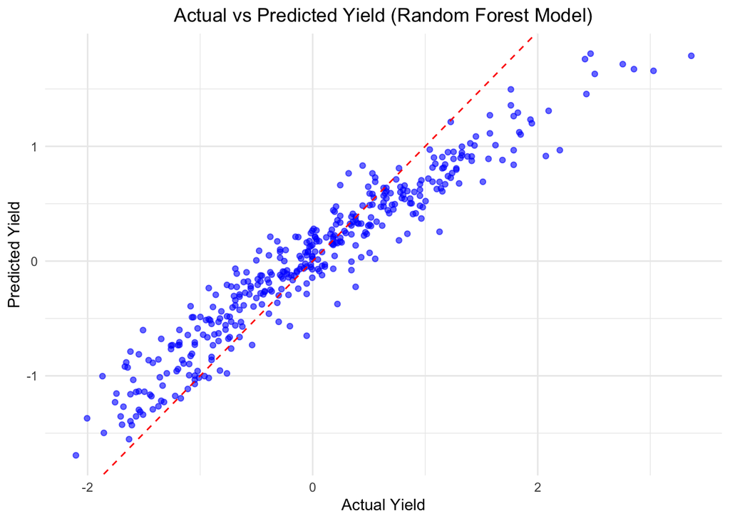

```r
# Create a data frame with Actual and Predicted values for comparsion
comparison_df <- data.frame(
  Actual = final_data$YLD,
  Predicted = rf_pred_final
)


ggplot(comparison_df, aes(x = Actual, y = Predicted)) +
  geom_point(color = "blue", alpha = 0.6) +
  geom_abline(slope = 1, intercept = 0, color = "red", linetype = "dashed") +
  theme_minimal() +
  labs(
    title = "Actual vs Predicted Yield (Random Forest Model)",
    x = "Actual Yield",
    y = "Predicted Yield"
  ) +
  theme(plot.title = element_text(hjust = 0.5))
```

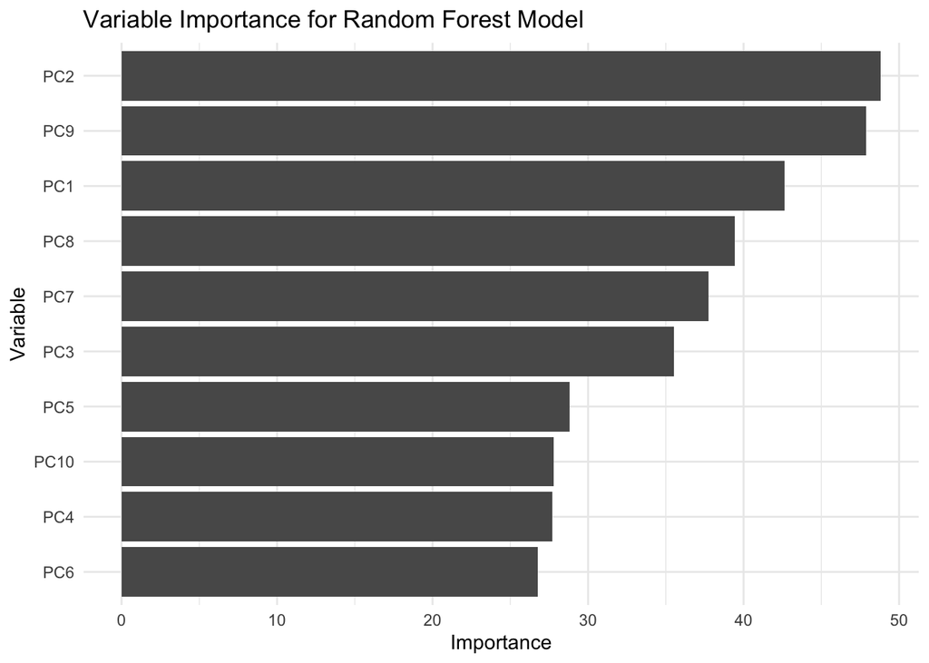

```r
# Plot variable importance
importance_rf <- importance(rf_best)
var_imp <- data.frame(Variable = rownames(importance_rf), Importance = importance_rf[,1])
var_imp <- var_imp[order(var_imp$Importance, decreasing = TRUE), ]

# Plot variable importance
ggplot(var_imp, aes(x = reorder(Variable, Importance), y = Importance)) +
  geom_bar(stat = "identity") +
  coord_flip() +
  theme_minimal() +
  labs(title = "Variable Importance for Random Forest Model", x = "Variable", y = "Importance")
```